Measuring elicitation in bill-conditioned forecasting

# Measuring elicitation in bill-conditioned forecasting

Nine enacted laws, first-print ground truth frozen before any model ran, about 7,400 scored runs varying model, reasoning effort, elicitation, and which part of the bill the forecaster sees. Every design committed to git before its first call; statistics independently re-derived. PolicyEngine × Thesis Institute hackathon, 2026-07-31.

TL;DR

- Recall-anchoring is keyed by the statute’s identity: with the law named, dose-response on a memorized 2021 target is flat; redact the name and the same doses go monotone in 4/4 cells, matching the unnamed 2026 arm (6/6). Directed derivation overrides the trigger even when the law is named; maximum reasoning effort does not. This correction came out of review: the original period framing was confounded with name-visibility, the deconfound arm was registered before running, and the name explanation won.
- One configuration validates out of sample at N=36 across 8 bill types (fable · bill · max effort): −0.094 [−0.174, −0.022] vs its own naive setup, −0.518 [−0.863, −0.228] vs persistence. The identical recipe at default effort is among the worst arms. Median-pooling its 5 repeats adds a further −0.013 [−0.022, −0.005].
- The recorded S.3596 poverty delta holds in 14/16 harness combinations; both outliers gave the model only the bill’s name. Per-configuration forward forecasts are recorded, so these comparisons keep resolving mechanically after today.
- At default effort, bill text narrowed intervals in 12/12 units while coverage fell; the added context made the models more certain of less accurate answers.
- An incomplete statutory excerpt degrades even tool-assisted runs; with complete text, PolicyEngine access takes every tier to 100% on the mechanical leg (the weakest tier alone: 4%).
- Three pipeline changes follow directly: two filed as PRs (#78 fail-closed quantile promotion, #79 reasoning-effort disclosure), a third proposed in review on the PolicyEngine tool PR.

Summary of the main findings

## Findings that contradict common configuration defaults.

[output not shown]

Result 1 · causal test

## Forecasts track the statute’s numbers only when its identity is hidden; naming the law switches the model to recall.

The dose-response table (rewrite a real statute’s $300/week supplement to $100/$900, on a memorized 2021 target vs an unmemorized 2026 one), and the chart of the same four conditions.

| condition | dose-response | reading |
| --- | --- | --- |
| Jan 2021 · standard elicitation | 0/3 monotone | forecasts sit at the realized value at every dose |
| Jan 2021 · max reasoning effort | 0/4 monotone | ~4,400 thinking tokens, same remembered number |
| Jan 2021 · directed derivation | 3/3 monotone | step-by-step derivation restores tracking |
| Jan 2021 · name redacted | 4/4 monotone | same statute, same doses, header anonymized; dose-response returns (3.0–9.6× noise) |
| Nov 2026 · any format | 6/6 monotone | rate × claimants × 52, composed onto the baseline |

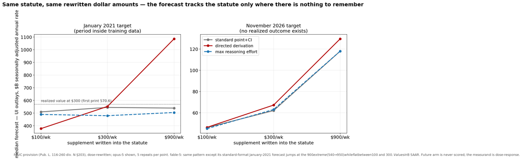

FPUC provision, dose-rewritten; opus-5 shown, 5 repeats per point; UI outlays, $B SAAR. Table denominators: cells are model × elicitation combinations, except the effort row, which counts effort levels. Replicated on a second statute (SNAP age caps: future 1.63× noise vs retro 0.44×) and a second parameter type (window length, linear within 1–2 units).

Result 2 · out-of-sample accuracy

## One configuration beats its baselines; added scaffolding does not.

The forest plot (every arm vs its own naive baseline, matched units, paired bootstrap CIs), then an interactive explorer over all measured configurations.

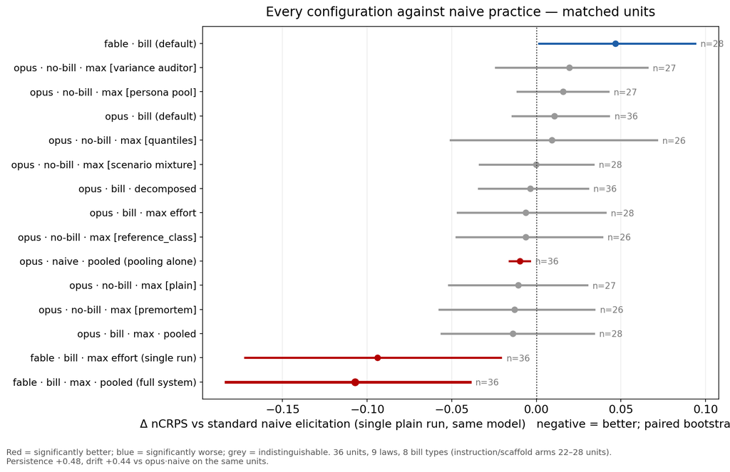

The full recommended system (fable · bill · max effort, five repeats median-pooled) beats one standard naive run by −0.107 [−0.183, −0.039]; the gap to its single-run row is the pooling increment. The same recipe on opus is indistinguishable from opus’s naive baseline (−0.014 [−0.056, +0.034], n=28): opus starts strong enough that neither the bill nor pooling adds much, and the significant gains concentrate on fable. Instruction styles and multi-stage scaffolds are indistinguishable from plain elicitation. Reference methods on the same units: persistence +0.48, drift +0.44 vs opus·naive.

### Configuration explorer

Pick a configuration; the readout shows aggregate accuracy (mean nCRPS, lower is better), 80% interval coverage, and the number of units it ran on. Arms cover different unit sets (instruction and scaffold arms never ran the 8 hardest new-type units), so cross-configuration readings here are exploratory; the forest plot above is the authoritative paired test.

**Where the margin lives.** Splitting units by an objective property, whether the realized move exceeded one history standard deviation: on the 17 big-realized-move units, the configured system beat persistence in 17 of 17 (Δ−1.016 [−1.606, −0.480]) and its own naive elicitation in 16 of 17 (Δ−0.225 [−0.342, −0.131]). On the 19 quiet units both comparisons are null. In relative terms the system’s mean nCRPS is 26% below naive elicitation and 66% below persistence. The stratifier uses the realized move, so it locates the skill after the fact; it is not an ex-ante selection rule.

**Changing only the reasoning-effort parameter.** With the model, prompt, and bill text held identical, moving the request’s effort setting from its default to max lowers fable’s mean nCRPS by 39% across the 28 common units (−0.131 [−0.205, −0.062]), and by 53% on the big-realized-move units, 10 wins in 10 (−0.335 [−0.439, −0.231]). Individual units move from 0.98 to 0.36 and from 0.85 to 0.30. The default setting is the one pipelines normally run at. The same change moves opus by 5% (not significant).

**Case study: one unit, three behaviors from the same model and bill**

**medicaid.us.2024-01** asks for Medicaid benefit outlays in January 2024 from a history that ends falling (793.7 → 783.0); the first print rebounded to 866.7. Naive fable, no bill text, extends the trend cautiously: 835. Fable with the bill at default effort reads the unwinding as a reason to go lower: 795, the worst answer of the three. Fable with the same bill at max effort reasons through the composition (in its own words, “disenrolled members are low-cost”), so outlays keep rising on per-enrollee cost growth and provider rates even as enrollment falls, and lands at a median of 865 across five repeats, 0.2% from the print, with all five intervals covering it. The elicitation format is identical in all three runs; what varies is context visibility and reasoning effort. The statute is identical in the second and third; the difference is whether the model has the budget to work out what the statute does to this particular series rather than which direction it sounds like. The unit sits inside the training window, so recall cannot be excluded; the reasoning is at least visible and economically coherent, which the 795 answer was not.

**Why bill text hurts fable at default effort: the mechanism**

Decomposing the damage on matched units: the loss is in point error (+0.082 SD), with intervals essentially unchanged in width; coverage falls because the points move, and run-to-run variance rises (+0.032 SD). The damage concentrates on Medicaid-unwinding units (Δ+0.110) and the WEP/GPO repeal; the FPUC units are unaffected. Direction on the worst units: the bill pushes forecasts further in the direction the statute implies, past the truth; on `ssfa.us.2025-03` the model’s own rationale reaches a nearly correct baseline (“near 1,520”; first print 1,516.2), then adds an $8–12B one-time retroactive payment, annualized ×12 by the series’ SAAR convention, and lands at 1,645. The bill text triggers an event adjustment whose direction is right and whose size and timing are guessed; at default effort the guess is aggressive, and annualization multiplies the miss. The same recipe at max effort sizes the adjustment and is the best measured arm, which is consistent with effort disciplining magnitude rather than changing direction.

**Case notes: four units worth reading individually**

**tariff301.us.2018-10** is the largest single-unit margin measured: fable·bill·max 1.09 vs persistence 4.13 (and 0.60 vs 3.74 on the second tariff unit). The Section 301 rate schedule is written in the notices, so a text-reader can project the collections staircase that extrapolation cannot see.

**iijahwy (appropriations)** shows a timing error persistence cannot make: on the June-2022 unit the model sits +1.07 SD above truth (outlays had not ramped; persistence wins, 0.33 vs 0.66), and on the December unit −0.94 SD below (the ramp arrived faster than it projected; it wins only because persistence is worse, 0.64 vs 2.01). The model mistimes the appropriations-to-outlays lag on both sides.

**ctcadv (advance CTC)** is the closest any family gets to exact: nCRPS 0.08 on both units. The payment window is written in §7527A with dates, and the level is flow arithmetic; a statute that specifies its own timing and magnitude leaves little for the forecast to guess.

**fpuc300 at default effort** is the exception that supports the recall account: bill text is harmless there (Δ−0.011) while damaging elsewhere, because the FPUC effect is inside the training window and the text adds nothing the model was not already pricing.

Robustness of the headline to its best units: excluding both tariff units, fable·bill·max still beats persistence −0.367 [−0.656, −0.133]; excluding the ctcadv pair as well, −0.194 [−0.325, −0.064] (n=32).

mean nCRPS

coverage (80% nominal)

units

Result 3 · robustness of a recorded number

## The recorded S.3596 delta under sixteen harness configurations.

The spread of the same registered forecast (child-poverty effect of the team’s demo bill) when re-run under 4 context levels × 2 elicitations × 2 models.

Fourteen of sixteen configurations land in a −0.10 to −0.30pp band. Both outliers are the *name-only* context: given just “S.3596, Stronger Start for Working Families Act”, one model swings to −1.5pp and another to 0.00. The uptake delta is sign-stable in 16/16 (+0.3 to +1.2M). Cells are medians of 3 repeats (one cell n=2). With the bill text present the registered number is stable across harnesses; the name-only cells justify requiring context disclosure alongside any published delta.

Result 4 · pipeline changes

## Three changes this suggests for the pipeline; two are open PRs.

Each measured finding mapped to a concrete change in the team’s code, with anchors.

| change | anchor | status |
| --- | --- | --- |
| Quantile-native runs fail closed instead of silently degrading to the interval transform (re-deriving costs 0.034 nCRPS [0.003, 0.068]) | run_thesis_analyst.py:291 | PR #78 |
| Harness disclosure on every forecast: reasoning effort recorded beside promptMode on predictionRun | cell-contract.md; spawned_cells_to_ts.py | PR #79 |
| Reform validation additionally checks amendatory completeness before pricing, plus a three-dose elasticity probe (the S.3596 §2(a)-without-§24(h)(6) case prices the wrong bill) | PR #64 checklist idiom | proposed in review |

Appendix

## Supporting results.

Collapsed by default: calibration, the two-legs comparison on S.3596, harness dispersion, the mechanical-leg tables, and the forward program.

**Calibration: bill text tightened intervals while coverage fell, and a sampling diagnostic locates why**

At default effort, adding bill text narrowed 80% intervals in 12/12 units while coverage fell 0.50 → 0.33. Comparing each run’s *stated* interval against the spread of its 5 repeated samples (728 cells): median revealed/stated ratio 0.26, and the ratio predicts miscalibration (ρ=0.209, p≈10<sup>−8</sup>). The same bill moved fable’s sampled spread with stated width flat (belief change) and narrowed opus’s stated width with sampled spread flat (confidence change). If quantiles are elicited, honour them: re-deriving through the fixed interval transform costs 0.034 nCRPS [0.003, 0.068].

**Both legs on the demo bill: mechanical −0.20pp vs forecast −0.10 to −0.15pp**

PR #64 prices S.3596 mechanically on a certified build: child poverty −0.20pp absolute (−1.2% relative), −$1.83B, gains bottom-concentrated. Our forecast-leg conditionals on the Census SPM 2027 target: −0.10 to −0.15pp. Different measure universes; read consistently the legs land within a factor of two, attenuated, consistent with the under-response to statutory content measured throughout. Composition (baseline + mechanical delta) can only be scored forward: on backtests the baseline already contains the enacted policy, so adding the delta double-counts it.

**Harness dispersion (corpus A) and the single-unit toggle**

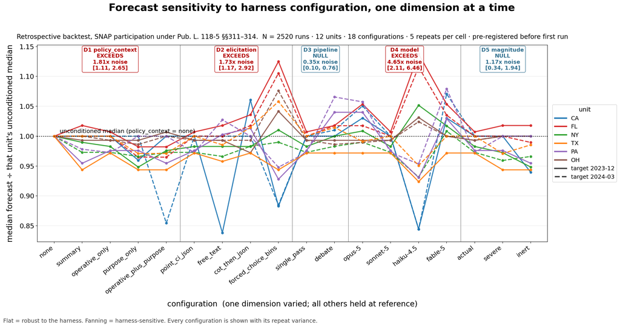

**Mechanical leg: tools close the tier gap; incomplete text defeats even tools**

S.3596 against 14 PolicyEngine-verified household cases, exact answers ±$1, unparseable counts as wrong (n=70/cell): with the tool, every tier reaches 100% (weakest tier without it: 4%). The trap: shown §2(a) without the conforming amendment, tool-free accuracy falls to 50% (below the 94% of a plain-language summary), and the tool cannot repair a mis-extracted parameter (86% with tool + incomplete text).

**Per-unit accuracy vs persistence**

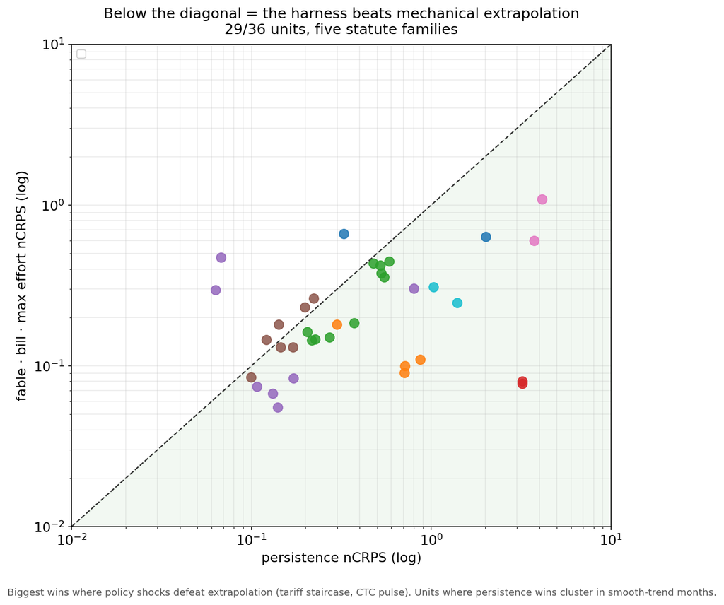

fable · bill · max vs persistence per unit, log-log; below the diagonal = the harness wins (29/36). Largest margins where statutory shocks defeat extrapolation.

**Forward program and chronology**

S.3596-conditional forecasts are recorded against two already-registered targets (census.spm.child_poverty_rate.2027; irs.soi.ctc.qualifying_children.ty2026, the latter carrying a behavioral-uptake claim against a mechanical zero), plus per-configuration lanes on near-resolving targets. Chronology: claimed-time from git history now; the recorder workflow on merge seals custody; witness tier requires re-emission as recorded runs. None of this depends on trusting today’s claims: the lab scores these mechanically as targets resolve.

Glossary

## What each configuration means.

Closed by default; definitions of every option in the explorer above. A terminology note: this page uses “elicitation” narrowly, for the answer-format dimension. In the capability-elicitation literature the word covers most of what is varied here (formats, scaffolds, reasoning effort, tools); “harness” there refers to the mechanical substrate that runs the model.

**Elicitation formats**

**point+CI**: one JSON answer, a point forecast plus an 80% interval. **decomposed**: the model states a no-policy baseline and a policy delta as separate numbers, then composes them. **plain**: point+CI with no additional instruction, at maximum reasoning effort. **premortem**: first forecast, then list the two most plausible ways it is wrong, then revise. **quantiles**: p10/p50/p90 elicited directly. **ref-class**: the model must state the base rate of comparable historical moves before adjusting.

**Multi-stage scaffolds**

**scenario mix**: the model assigns probabilities to four scenarios with values; the harness computes the mixture quantiles. **var-auditor**: a second pass whose only job is to audit and reprice interval width. **persona panel**: three prior-diverse forecasters (momentum, mean-reversion, base-rate) pooled by a synthesizer. This is a prompting scaffold; it is unrelated to the “median of 5 runs” aggregation option.

**Aggregation**

**single run**: scores average the 5 independent repeats, i.e. the expected quality of one run. **median of 5 runs**: the five repeats are pooled into one forecast (median point and interval bounds) before scoring. Pooling improves every arm it applies to; on the leading configuration it moves nCRPS from 0.264 to 0.251 and coverage from 0.77 to 0.81 (gain −0.013 [−0.022, −0.005], 30/36 units).

**Context and effort**

**none / bill**: whether the statute’s operative text is in the prompt. **default / max effort**: the reasoning-effort setting on the request; max forces extended reasoning regardless of how easy the task looks. Instruction styles and scaffolds ran at opus · no-bill · max only, so selecting one snaps the other dials to the nearest measured configuration instead of showing a dead end.

N is stated on every table. 48 retrospective units span the two corpora; the 12 dispersion-corpus units (6 states × 2 months) are not independent and are disjoint from the 36-unit accuracy corpus; retrospective accuracy sits inside model training windows and is treated as an upper bound throughout (Result 1’s point). All designs and amendments were committed before their runs; instrument defects found during the day were quarantined, corrected, and documented in the repository. Full record: PR #61.